# Tutorial 6 Solutions: Building Toward Hodgkin-Huxley

Author: Matthew J. Crossley

Last update: 26 May, 2026

## Notes

- This page is intended as a check-your-work sheet for the week 6 tutorial.
- The code below is complete and runnable.
- The written answers are deliberately short. Students may phrase them differently and still be correct if the logic is sound.
- Main conceptual checkpoints:
  - outward-positive current means positive current tends to pull voltage down when subtracted from `I_ext`
  - `m` drives rapid Na$^+$ activation
  - `h` shuts Na$^+$ down during sustained depolarization
  - `n` provides delayed K$^+$ activation and helps repolarize the membrane

## 1. Passive membrane with potassium only

### Short answers

1. The membrane returns to the same baseline because the only equilibrium in the model is at `V = E_K`.
2. During a depolarizing pulse, K$^+$ current is outward because `V > E_K`, so it opposes the depolarization.
3. Increasing the pulse amplitude produces a larger voltage deflection, but the system still relaxes back to the same equilibrium.

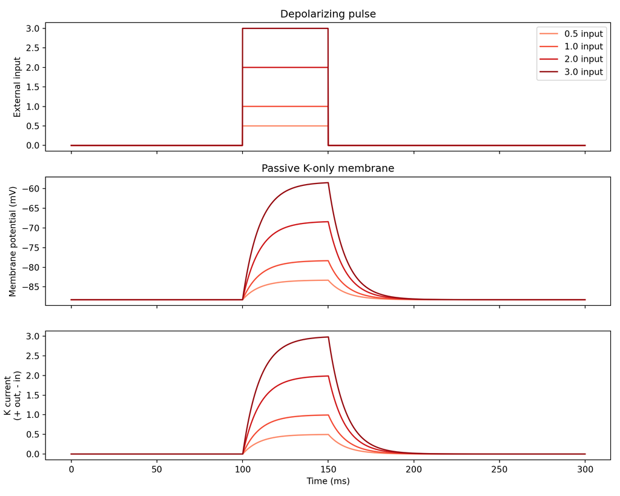

```python
import numpy as np
import matplotlib.pyplot as plt
from matplotlib import cm

K_in = 140
K_out = 5
E_K = 61 * np.log10(K_out / K_in)
tau = 10

T = 300
dt = 0.1
t = np.arange(0, T, dt)
N = len(t)

pulse_amps = [0.5, 1.0, 2.0, 3.0]
colors = cm.Reds(np.linspace(0.4, 0.9, len(pulse_amps)))
pulse_width = N // 6
start = N // 3
end = start + pulse_width

V_traces = []
I_K_traces = []
I_ext_traces = []

for amp in pulse_amps:
    I_ext = np.zeros(N)
    I_ext[start:end] = amp

    V = np.zeros(N)
    V[0] = E_K
    I_K = np.zeros(N)
    I_K[0] = (V[0] - E_K) / tau

    for i in range(1, N):
        I_K[i] = (V[i - 1] - E_K) / tau
        dVdt = I_ext[i - 1] - I_K[i]
        V[i] = V[i - 1] + dVdt * dt

    V_traces.append(V)
    I_K_traces.append(I_K)
    I_ext_traces.append(I_ext)

fig, ax = plt.subplots(3, 1, figsize=(10, 8), sharex=True)

for i, I_ext in enumerate(I_ext_traces):
    ax[0].plot(t, I_ext, label=f'{pulse_amps[i]} input', color=colors[i])
ax[0].set_ylabel('External input')
ax[0].set_title('Depolarizing pulse')

for i, V in enumerate(V_traces):
    ax[1].plot(t, V, color=colors[i])
ax[1].set_ylabel('Membrane potential (mV)')
ax[1].set_title('Passive K-only membrane')

for i, I_K in enumerate(I_K_traces):
    ax[2].plot(t, I_K, color=colors[i])
ax[2].set_ylabel('K current\n(+ out, - in)')
ax[2].set_xlabel('Time (ms)')

ax[0].legend(loc='upper right')
plt.tight_layout()
plt.show()
```

## 2. Passive membrane with potassium and sodium

### Short answers

1. The resting potential moves away from `E_K` and toward `E_Na`, but stays much closer to `E_K`.
2. It stays closer to `E_K` because `g_K > g_Na`.
3. Increasing `g_Na` raises the starting voltage because Na$^+$ pulls the weighted resting potential upward.
4. The model is still passive because the conductances are fixed and do not depend on voltage or time.

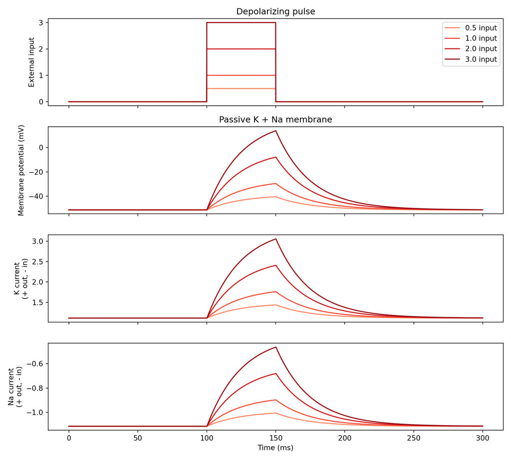

```python
import numpy as np
import matplotlib.pyplot as plt
from matplotlib import cm

K_in = 140
K_out = 5
Na_in = 15
Na_out = 145
E_K = 61 * np.log10(K_out / K_in)
E_Na = 61 * np.log10(Na_out / Na_in)
g_K = 0.3
g_Na = 0.1
tau = 10

T = 300
dt = 0.1
t = np.arange(0, T, dt)
N = len(t)

pulse_amps = [0.5, 1.0, 2.0, 3.0]
colors = cm.Reds(np.linspace(0.4, 0.9, len(pulse_amps)))
pulse_width = N // 6
start = N // 3
end = start + pulse_width

V_rest = (g_K * E_K + g_Na * E_Na) / (g_K + g_Na)

V_traces = []
I_K_traces = []
I_Na_traces = []
I_ext_traces = []

for amp in pulse_amps:
    I_ext = np.zeros(N)
    I_ext[start:end] = amp

    V = np.zeros(N)
    V[0] = V_rest
    I_K = np.zeros(N)
    I_Na = np.zeros(N)

    I_K[0] = g_K * (V[0] - E_K) / tau
    I_Na[0] = g_Na * (V[0] - E_Na) / tau

    for i in range(1, N):
        I_K[i] = g_K * (V[i - 1] - E_K) / tau
        I_Na[i] = g_Na * (V[i - 1] - E_Na) / tau
        dVdt = I_ext[i - 1] - (I_K[i] + I_Na[i])
        V[i] = V[i - 1] + dVdt * dt

    V_traces.append(V)
    I_K_traces.append(I_K)
    I_Na_traces.append(I_Na)
    I_ext_traces.append(I_ext)

fig, ax = plt.subplots(4, 1, figsize=(10, 9), sharex=True)

for i, I_ext in enumerate(I_ext_traces):
    ax[0].plot(t, I_ext, label=f'{pulse_amps[i]} input', color=colors[i])
ax[0].set_ylabel('External input')
ax[0].set_title('Depolarizing pulse')

for i, V in enumerate(V_traces):
    ax[1].plot(t, V, color=colors[i])
ax[1].set_ylabel('Membrane potential (mV)')
ax[1].set_title('Passive K + Na membrane')

for i, I_K in enumerate(I_K_traces):
    ax[2].plot(t, I_K, color=colors[i])
ax[2].set_ylabel('K current\n(+ out, - in)')

for i, I_Na in enumerate(I_Na_traces):
    ax[3].plot(t, I_Na, color=colors[i])
ax[3].set_ylabel('Na current\n(+ out, - in)')
ax[3].set_xlabel('Time (ms)')

ax[0].legend(loc='upper right')
plt.tight_layout()
plt.show()
```

## 3. Smooth voltage-dependent sodium conductance

### Short answers

1. Small inputs look mostly passive, while large inputs produce a more regenerative upswing.
2. The response starts to look regenerative once depolarization moves the membrane into the steep part of the Na$^+$ activation sigmoid.
3. This is not yet a realistic spike model because there is no Na$^+$ inactivation and no delayed K$^+$ activation.
4. Making `V_half` more negative or reducing the slope makes the apparent threshold easier to reach.

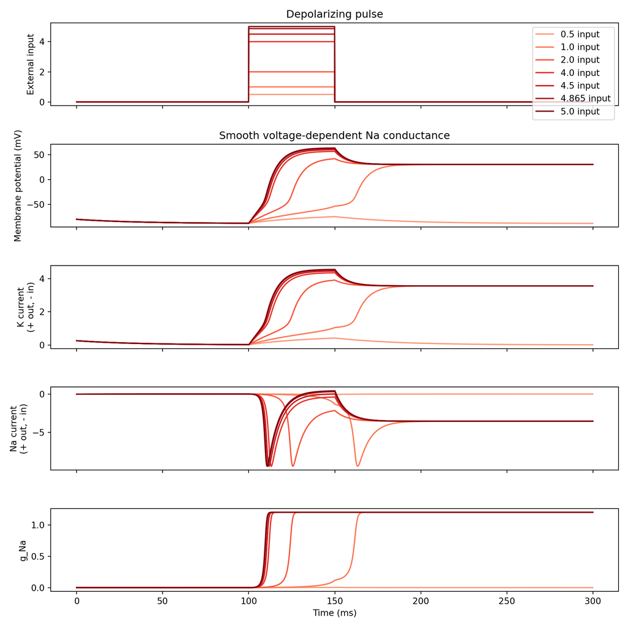

```python
import numpy as np
import matplotlib.pyplot as plt
from matplotlib import cm

K_in = 140
K_out = 5
Na_in = 15
Na_out = 145
E_K = 61 * np.log10(K_out / K_in)
E_Na = 61 * np.log10(Na_out / Na_in)
g_K = 0.3
g_Na_max = 1.2
tau = 10

def sigmoid(V, V_half=-40, slope=6):
    return 1 / (1 + np.exp(-(V - V_half) / slope))

T = 300
dt = 0.1
t = np.arange(0, T, dt)
N = len(t)

pulse_amps = [0.5, 1.0, 2.0, 4.0, 4.5, 4.865, 5.0]
colors = cm.Reds(np.linspace(0.35, 0.95, len(pulse_amps)))
pulse_width = N // 6
start = N // 3
end = start + pulse_width

g_Na_rest = g_Na_max * sigmoid(-65)
V_rest = (g_K * E_K + g_Na_rest * E_Na) / (g_K + g_Na_rest)

V_traces = []
I_K_traces = []
I_Na_traces = []
g_Na_traces = []
I_ext_traces = []

for amp in pulse_amps:
    I_ext = np.zeros(N)
    I_ext[start:end] = amp

    V = np.zeros(N)
    V[0] = V_rest
    I_K = np.zeros(N)
    I_Na = np.zeros(N)
    g_Na = np.zeros(N)

    g_Na[0] = g_Na_max * sigmoid(V[0])
    I_K[0] = g_K * (V[0] - E_K) / tau
    I_Na[0] = g_Na[0] * (V[0] - E_Na) / tau

    for i in range(1, N):
        g_Na[i] = g_Na_max * sigmoid(V[i - 1])
        I_K[i] = g_K * (V[i - 1] - E_K) / tau
        I_Na[i] = g_Na[i] * (V[i - 1] - E_Na) / tau
        dVdt = I_ext[i - 1] - (I_K[i] + I_Na[i])
        V[i] = V[i - 1] + dVdt * dt

    V_traces.append(V)
    I_K_traces.append(I_K)
    I_Na_traces.append(I_Na)
    g_Na_traces.append(g_Na)
    I_ext_traces.append(I_ext)

fig, ax = plt.subplots(5, 1, figsize=(10, 10), sharex=True)

for i, I_ext in enumerate(I_ext_traces):
    ax[0].plot(t, I_ext, label=f'{pulse_amps[i]} input', color=colors[i])
ax[0].set_ylabel('External input')
ax[0].set_title('Depolarizing pulse')

for i, V in enumerate(V_traces):
    ax[1].plot(t, V, color=colors[i])
ax[1].set_ylabel('Membrane potential (mV)')
ax[1].set_title('Smooth voltage-dependent Na conductance')

for i, I_K in enumerate(I_K_traces):
    ax[2].plot(t, I_K, color=colors[i])
ax[2].set_ylabel('K current\n(+ out, - in)')

for i, I_Na in enumerate(I_Na_traces):
    ax[3].plot(t, I_Na, color=colors[i])
ax[3].set_ylabel('Na current\n(+ out, - in)')

for i, g_Na in enumerate(g_Na_traces):
    ax[4].plot(t, g_Na, color=colors[i])
ax[4].set_ylabel('g_Na')
ax[4].set_xlabel('Time (ms)')

ax[0].legend(loc='upper right')
plt.tight_layout()
plt.show()
```

## 4. Active sodium channels: activation and inactivation

### Short answers

1. `m(t)` rises quickly with depolarization, while `h(t)` falls more slowly.
2. Na$^+$ conductance increases because `m` activates, then decreases because `h` inactivates the channel population.
3. The early rise is mainly due to `m`; the later fall is mainly due to `h`.
4. This is still not a full HH spike model because K$^+$ is not yet voltage-gated with its own delayed activation variable.

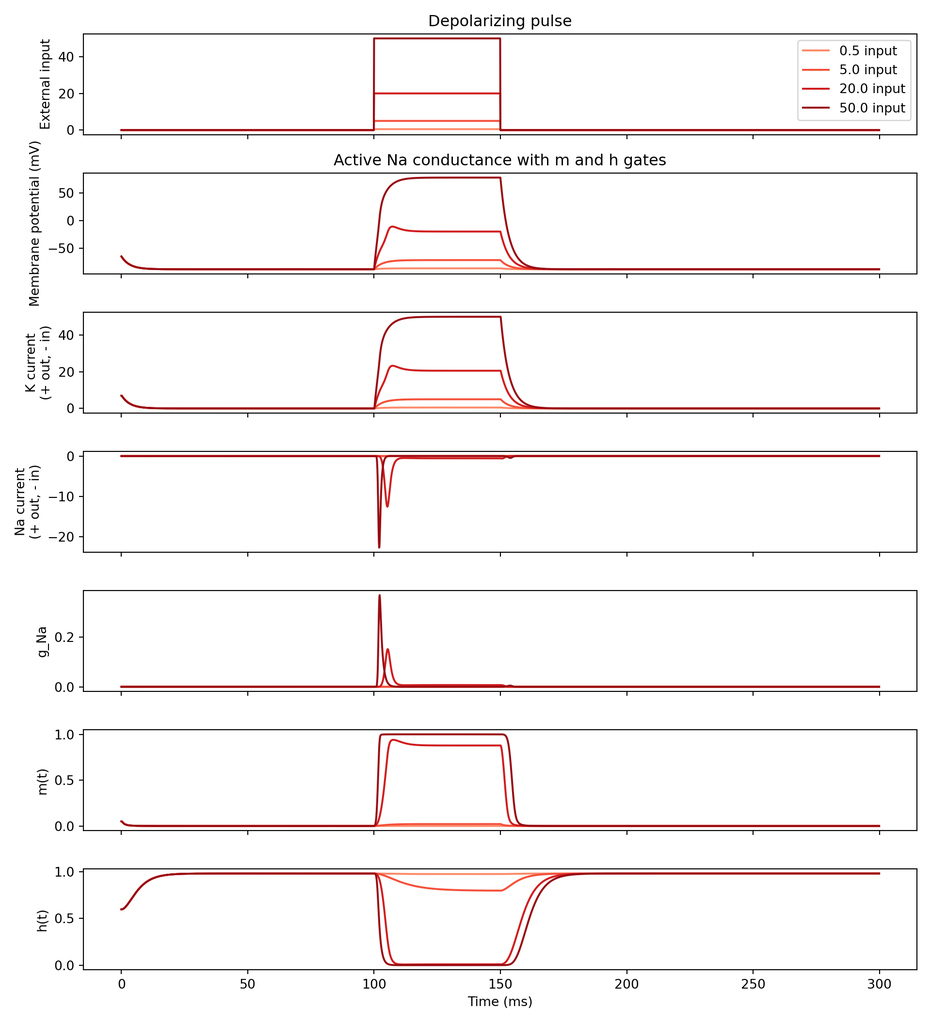

```python
import numpy as np
import matplotlib.pyplot as plt
from matplotlib import cm

K_in = 140
K_out = 5
Na_in = 15
Na_out = 145
E_K = 61 * np.log10(K_out / K_in)
E_Na = 61 * np.log10(Na_out / Na_in)
g_K = 0.3
g_Na_max = 1.2

def alpha_m(V):
    x = V + 40
    return np.where(np.abs(x) < 1e-6, 1.0, 0.1 * x / (1 - np.exp(-x / 10)))

def beta_m(V):
    return 4.0 * np.exp(-(V + 65) / 18)

def alpha_h(V):
    return 0.07 * np.exp(-(V + 65) / 20)

def beta_h(V):
    return 1 / (1 + np.exp(-(V + 35) / 10))

T = 300
dt = 0.1
t = np.arange(0, T, dt)
N = len(t)

pulse_amps = [0.5, 5.0, 20.0, 50.0]
colors = cm.Reds(np.linspace(0.4, 0.9, len(pulse_amps)))
pulse_width = N // 6
start = N // 3
end = start + pulse_width

V_traces = []
I_K_traces = []
I_Na_traces = []
m_traces = []
h_traces = []
g_Na_traces = []
I_ext_traces = []

for amp in pulse_amps:
    I_ext = np.zeros(N)
    I_ext[start:end] = amp

    V = np.zeros(N)
    V[0] = -65
    m = np.zeros(N)
    h = np.zeros(N)
    g_Na = np.zeros(N)
    I_K = np.zeros(N)
    I_Na = np.zeros(N)

    m[0] = alpha_m(V[0]) / (alpha_m(V[0]) + beta_m(V[0]))
    h[0] = alpha_h(V[0]) / (alpha_h(V[0]) + beta_h(V[0]))
    g_Na[0] = g_Na_max * m[0]**3 * h[0]
    I_K[0] = g_K * (V[0] - E_K)
    I_Na[0] = g_Na[0] * (V[0] - E_Na)

    for i in range(1, N):
        a_m = alpha_m(V[i - 1])
        b_m = beta_m(V[i - 1])
        a_h = alpha_h(V[i - 1])
        b_h = beta_h(V[i - 1])

        tau_m = 1 / (a_m + b_m)
        tau_h = 1 / (a_h + b_h)
        m_inf = a_m * tau_m
        h_inf = a_h * tau_h

        m[i] = m[i - 1] + (m_inf - m[i - 1]) / tau_m * dt
        h[i] = h[i - 1] + (h_inf - h[i - 1]) / tau_h * dt

        g_Na[i] = g_Na_max * m[i]**3 * h[i]
        I_K[i] = g_K * (V[i - 1] - E_K)
        I_Na[i] = g_Na[i] * (V[i - 1] - E_Na)
        dVdt = I_ext[i - 1] - (I_K[i] + I_Na[i])
        V[i] = V[i - 1] + dVdt * dt

    V_traces.append(V)
    I_K_traces.append(I_K)
    I_Na_traces.append(I_Na)
    m_traces.append(m)
    h_traces.append(h)
    g_Na_traces.append(g_Na)
    I_ext_traces.append(I_ext)

fig, ax = plt.subplots(7, 1, figsize=(10, 11), sharex=True)

for i, I_ext in enumerate(I_ext_traces):
    ax[0].plot(t, I_ext, label=f'{pulse_amps[i]} input', color=colors[i])
ax[0].set_ylabel('External input')
ax[0].set_title('Depolarizing pulse')

for i, V in enumerate(V_traces):
    ax[1].plot(t, V, color=colors[i])
ax[1].set_ylabel('Membrane potential (mV)')
ax[1].set_title('Active Na conductance with m and h gates')

for i, I_K in enumerate(I_K_traces):
    ax[2].plot(t, I_K, color=colors[i])
ax[2].set_ylabel('K current\n(+ out, - in)')

for i, I_Na in enumerate(I_Na_traces):
    ax[3].plot(t, I_Na, color=colors[i])
ax[3].set_ylabel('Na current\n(+ out, - in)')

for i, g_Na in enumerate(g_Na_traces):
    ax[4].plot(t, g_Na, color=colors[i])
ax[4].set_ylabel('g_Na')

for i, m in enumerate(m_traces):
    ax[5].plot(t, m, color=colors[i])
ax[5].set_ylabel('m(t)')

for i, h in enumerate(h_traces):
    ax[6].plot(t, h, color=colors[i])
ax[6].set_ylabel('h(t)')
ax[6].set_xlabel('Time (ms)')

ax[0].legend(loc='upper right')
plt.tight_layout()
plt.show()
```

## 5. Active sodium, active potassium, and leak: a simplified HH model

### Short answers

1. Small input stays subthreshold, larger input can produce a spike-like response, and the strongest input produces the largest excursion.
2. The upstroke is dominated by inward Na$^+$ current, which appears as negative `I_Na` in the outward-positive sign convention.
3. Repolarization is dominated by outward K$^+$ current, supported by Na$^+$ inactivation.
4. `m` changes fastest, `h` is slower, and `n` is delayed and slower still.

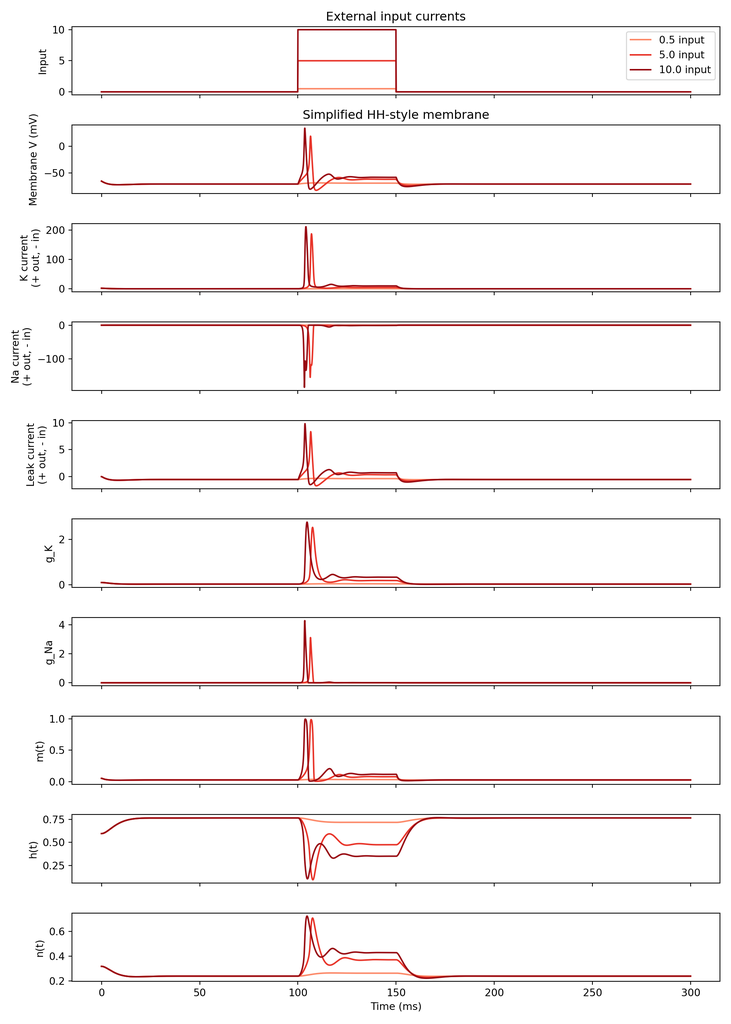

```python
import numpy as np
import matplotlib.pyplot as plt
from matplotlib import cm

K_in = 140
K_out = 5
Na_in = 15
Na_out = 145
E_K = 61 * np.log10(K_out / K_in)
E_Na = 61 * np.log10(Na_out / Na_in)
E_L = -65
g_K_max = 10
g_Na_max = 15
g_L = 0.1

def alpha_m(V):
    x = V + 40
    return np.where(np.abs(x) < 1e-6, 1.0, 0.1 * x / (1 - np.exp(-x / 10)))

def beta_m(V):
    return 4.0 * np.exp(-(V + 65) / 18)

def alpha_h(V):
    return 0.07 * np.exp(-(V + 65) / 20)

def beta_h(V):
    return 1 / (1 + np.exp(-(V + 35) / 10))

def alpha_n(V):
    x = V + 55
    return np.where(np.abs(x) < 1e-6, 0.1, 0.01 * x / (1 - np.exp(-x / 10)))

def beta_n(V):
    return 0.125 * np.exp(-(V + 65) / 80)

T = 300
dt = 0.1
t = np.arange(0, T, dt)
N = len(t)

pulse_amps = [0.5, 5.0, 10.0]
colors = cm.Reds(np.linspace(0.4, 0.9, len(pulse_amps)))
pulse_width = N // 6
start = N // 3
end = start + pulse_width

V_traces = []
I_K_traces = []
I_Na_traces = []
I_L_traces = []
g_K_traces = []
g_Na_traces = []
m_traces = []
h_traces = []
n_traces = []
I_ext_traces = []

for amp in pulse_amps:
    I_ext = np.zeros(N)
    I_ext[start:end] = amp

    V = np.zeros(N)
    V[0] = -65
    m = np.zeros(N)
    h = np.zeros(N)
    n = np.zeros(N)
    g_K = np.zeros(N)
    g_Na = np.zeros(N)
    I_K = np.zeros(N)
    I_Na = np.zeros(N)
    I_L = np.zeros(N)

    m[0] = alpha_m(V[0]) / (alpha_m(V[0]) + beta_m(V[0]))
    h[0] = alpha_h(V[0]) / (alpha_h(V[0]) + beta_h(V[0]))
    n[0] = alpha_n(V[0]) / (alpha_n(V[0]) + beta_n(V[0]))

    g_K[0] = g_K_max * n[0]**4
    g_Na[0] = g_Na_max * m[0]**3 * h[0]
    I_K[0] = g_K[0] * (V[0] - E_K)
    I_Na[0] = g_Na[0] * (V[0] - E_Na)
    I_L[0] = g_L * (V[0] - E_L)

    for i in range(1, N):
        a_m = alpha_m(V[i - 1])
        b_m = beta_m(V[i - 1])
        a_h = alpha_h(V[i - 1])
        b_h = beta_h(V[i - 1])
        a_n = alpha_n(V[i - 1])
        b_n = beta_n(V[i - 1])

        tau_m = 1 / (a_m + b_m)
        tau_h = 1 / (a_h + b_h)
        tau_n = 1 / (a_n + b_n)

        m_inf = a_m * tau_m
        h_inf = a_h * tau_h
        n_inf = a_n * tau_n

        m[i] = m[i - 1] + (m_inf - m[i - 1]) / tau_m * dt
        h[i] = h[i - 1] + (h_inf - h[i - 1]) / tau_h * dt
        n[i] = n[i - 1] + (n_inf - n[i - 1]) / tau_n * dt

        g_K[i] = g_K_max * n[i]**4
        g_Na[i] = g_Na_max * m[i]**3 * h[i]
        I_K[i] = g_K[i] * (V[i - 1] - E_K)
        I_Na[i] = g_Na[i] * (V[i - 1] - E_Na)
        I_L[i] = g_L * (V[i - 1] - E_L)

        dVdt = I_ext[i - 1] - (I_K[i] + I_Na[i] + I_L[i])
        V[i] = V[i - 1] + dVdt * dt

    V_traces.append(V)
    I_K_traces.append(I_K)
    I_Na_traces.append(I_Na)
    I_L_traces.append(I_L)
    g_K_traces.append(g_K)
    g_Na_traces.append(g_Na)
    m_traces.append(m)
    h_traces.append(h)
    n_traces.append(n)
    I_ext_traces.append(I_ext)

fig, ax = plt.subplots(10, 1, figsize=(10, 14), sharex=True)

for i, I_ext in enumerate(I_ext_traces):
    ax[0].plot(t, I_ext, label=f'{pulse_amps[i]} input', color=colors[i])
ax[0].set_ylabel('Input')
ax[0].set_title('External input currents')

for i, V in enumerate(V_traces):
    ax[1].plot(t, V, color=colors[i])
ax[1].set_ylabel('Membrane V (mV)')
ax[1].set_title('Simplified HH-style membrane')

for i, I_K in enumerate(I_K_traces):
    ax[2].plot(t, I_K, color=colors[i])
ax[2].set_ylabel('K current\n(+ out, - in)')

for i, I_Na in enumerate(I_Na_traces):
    ax[3].plot(t, I_Na, color=colors[i])
ax[3].set_ylabel('Na current\n(+ out, - in)')

for i, I_L in enumerate(I_L_traces):
    ax[4].plot(t, I_L, color=colors[i])
ax[4].set_ylabel('Leak current\n(+ out, - in)')

for i, g_K in enumerate(g_K_traces):
    ax[5].plot(t, g_K, color=colors[i])
ax[5].set_ylabel('g_K')

for i, g_Na in enumerate(g_Na_traces):
    ax[6].plot(t, g_Na, color=colors[i])
ax[6].set_ylabel('g_Na')

for i, m in enumerate(m_traces):
    ax[7].plot(t, m, color=colors[i])
ax[7].set_ylabel('m(t)')

for i, h in enumerate(h_traces):
    ax[8].plot(t, h, color=colors[i])
ax[8].set_ylabel('h(t)')

for i, n in enumerate(n_traces):
    ax[9].plot(t, n, color=colors[i])
ax[9].set_ylabel('n(t)')
ax[9].set_xlabel('Time (ms)')

ax[0].legend(loc='upper right')
plt.tight_layout()
plt.show()
```

## 6. HH capstone: response to current injection

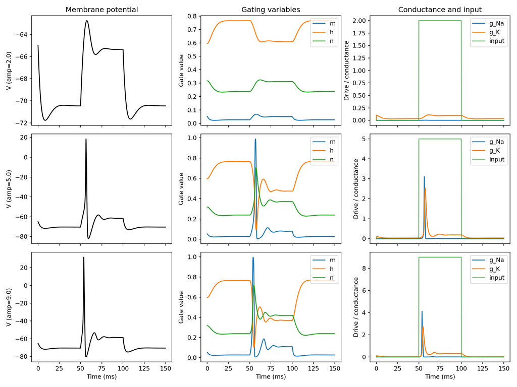

```python
import numpy as np
import matplotlib.pyplot as plt

K_in = 140
K_out = 5
Na_in = 15
Na_out = 145
E_K = 61 * np.log10(K_out / K_in)
E_Na = 61 * np.log10(Na_out / Na_in)
E_L = -65
g_K_max = 10
g_Na_max = 15
g_L = 0.1

def alpha_m(V):
    x = V + 40
    return np.where(np.abs(x) < 1e-6, 1.0, 0.1 * x / (1 - np.exp(-x / 10)))

def beta_m(V):
    return 4.0 * np.exp(-(V + 65) / 18)

def alpha_h(V):
    return 0.07 * np.exp(-(V + 65) / 20)

def beta_h(V):
    return 1 / (1 + np.exp(-(V + 35) / 10))

def alpha_n(V):
    x = V + 55
    return np.where(np.abs(x) < 1e-6, 0.1, 0.01 * x / (1 - np.exp(-x / 10)))

def beta_n(V):
    return 0.125 * np.exp(-(V + 65) / 80)

def simulate_hh_like(amp, g_na_max=g_Na_max, g_k_max=g_K_max, g_leak=g_L):
    T = 150
    dt = 0.1
    t = np.arange(0, T, dt)
    N = len(t)

    I_ext = np.zeros(N)
    I_ext[(t >= 50) & (t < 100)] = amp

    V = np.zeros(N)
    V[0] = -65
    m = np.zeros(N)
    h = np.zeros(N)
    n = np.zeros(N)
    g_K = np.zeros(N)
    g_Na = np.zeros(N)

    m[0] = alpha_m(V[0]) / (alpha_m(V[0]) + beta_m(V[0]))
    h[0] = alpha_h(V[0]) / (alpha_h(V[0]) + beta_h(V[0]))
    n[0] = alpha_n(V[0]) / (alpha_n(V[0]) + beta_n(V[0]))

    for i in range(1, N):
        a_m = alpha_m(V[i - 1])
        b_m = beta_m(V[i - 1])
        a_h = alpha_h(V[i - 1])
        b_h = beta_h(V[i - 1])
        a_n = alpha_n(V[i - 1])
        b_n = beta_n(V[i - 1])

        tau_m = 1 / (a_m + b_m)
        tau_h = 1 / (a_h + b_h)
        tau_n = 1 / (a_n + b_n)

        m_inf = a_m * tau_m
        h_inf = a_h * tau_h
        n_inf = a_n * tau_n

        m[i] = m[i - 1] + (m_inf - m[i - 1]) / tau_m * dt
        h[i] = h[i - 1] + (h_inf - h[i - 1]) / tau_h * dt
        n[i] = n[i - 1] + (n_inf - n[i - 1]) / tau_n * dt

        g_K[i] = g_k_max * n[i]**4
        g_Na[i] = g_na_max * m[i]**3 * h[i]

        I_K = g_K[i] * (V[i - 1] - E_K)
        I_Na = g_Na[i] * (V[i - 1] - E_Na)
        I_L = g_leak * (V[i - 1] - E_L)

        dVdt = I_ext[i - 1] - (I_K + I_Na + I_L)
        V[i] = V[i - 1] + dVdt * dt

    return t, V, m, h, n, g_Na, g_K, I_ext

amps = [2.0, 5.0, 9.0]
results = [simulate_hh_like(amp) for amp in amps]

fig, ax = plt.subplots(3, 3, figsize=(12, 9), sharex=True)

for row, (amp, res) in enumerate(zip(amps, results)):
    t, V, m, h, n, g_Na, g_K, I_ext = res

    ax[row, 0].plot(t, V, '-k')
    ax[row, 0].set_ylabel(f'V (amp={amp})')

    ax[row, 1].plot(t, m, label='m')
    ax[row, 1].plot(t, h, label='h')
    ax[row, 1].plot(t, n, label='n')
    ax[row, 1].set_ylabel('Gate value')
    ax[row, 1].legend(loc='upper right')

    ax[row, 2].plot(t, g_Na, label='g_Na')
    ax[row, 2].plot(t, g_K, label='g_K')
    ax[row, 2].plot(t, I_ext, label='input', alpha=0.7)
    ax[row, 2].set_ylabel('Drive / conductance')
    ax[row, 2].legend(loc='upper right')

ax[0, 0].set_title('Membrane potential')
ax[0, 1].set_title('Gating variables')
ax[0, 2].set_title('Conductance and input')

for col in range(3):
    ax[2, col].set_xlabel('Time (ms)')

plt.tight_layout()
plt.show()
```

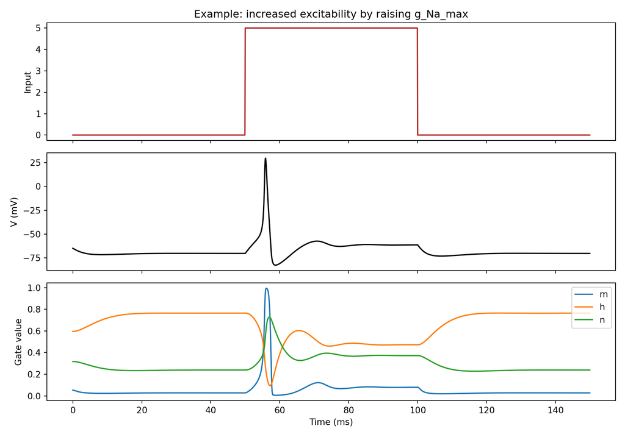

```python
# Example excitability manipulation for the medium case:
t, V, m, h, n, g_Na, g_K, I_ext = simulate_hh_like(5.0, g_na_max=18)

fig, ax = plt.subplots(3, 1, figsize=(10, 7), sharex=True)
ax[0].plot(t, I_ext, color='firebrick')
ax[0].set_ylabel('Input')
ax[0].set_title('Example: increased excitability by raising g_Na_max')

ax[1].plot(t, V, color='black')
ax[1].set_ylabel('V (mV)')

ax[2].plot(t, m, label='m')
ax[2].plot(t, h, label='h')
ax[2].plot(t, n, label='n')
ax[2].set_ylabel('Gate value')
ax[2].set_xlabel('Time (ms)')
ax[2].legend(loc='upper right')

plt.tight_layout()
plt.show()
```

## Wrap-up questions

### Short answers

1. Section 2 added a second passive ion; section 3 added voltage-dependent Na$^+$ conductance; section 4 added Na$^+$ activation and inactivation gates; section 5 added delayed K$^+$ activation and leak.
2. Strong positive feedback first appears in section 3.
3. A realistic spike-and-recovery shape first appears in section 5.
4. Na$^+$ inactivation is necessary so inward Na$^+$ current does not stay large indefinitely during depolarization.
5. Delayed K$^+$ activation is necessary because it provides a robust outward current that repolarizes the membrane.